# ECI 254 - Midterm

Tareq & Anirudh

2/19/2021

## Demographic and Social Indices Anlysis for COVID-19

### Introduction and Data cleaning

```r
# installing necessary packages
#install.packages('ggeasy')
library(ggeasy)
#install.packages('ggpmisc')
library(ggpmisc)
library(tidyverse)
library(data.table)

#data<-fread('Data/COVID-19_Case_Surveillance_Public_Use_Data.csv')
data<-read_csv('data/COVID-19.CSV')
#use the above



# mydata<-data[data$cdc_case_earliest_dt>'2020-11-30',]

mydata<-data

# new data frome
new_data<- mydata%>%
  select(cdc_case_earliest_dt,sex, age_group, race_ethnicity_combined, medcond_yn, icu_yn,death_yn, hosp_yn)


#----------------------------------------------------------------------------------------------------------

# general cleaning of data
new_data$medcond_yn[new_data$medcond_yn=='Missing']<-NA
new_data$icu_yn[new_data$icu_yn=='Missing']<-NA
new_data$death_yn[new_data$death_yn=='Missing']<-NA
new_data$hosp_yn[new_data$hosp_yn=='Missing']<-NA
new_data$age_group[new_data$age_group=='Missing']<-NA


# defining a new data frame
mydata1<-new_data
```

#### Data Sources/ Gathering and Data Cleaning

*COVID-19 Case Surveillance Public Use Dataset*

This dataset is managed by the Centers for Disease Control and Prevention (CDC), and it includes individual-level information reported to the different U.S. states and autonomous reporting agencies. Besides, this dataset is overseen by the Case Surveillance Task Force and Surveillance Review Response Group (SRRG) to ensure individual confidentiality. Also, different data cleaning/quality assurance procedures have been implemented on such data. Some of those tools include reclassifying unanswered questions as needed and applicable and performing logical checks to address data errors. Furthermore, this public use dataset has 18,379,871 observations with 11 variables, including information about demographic characteristics, exposure history to the virus, clinical and laboratory data, diagnostic test results, hospital/intensive care unit admissions, and death status.

$~$

*Data cleaning*

### Exploratory Data analysis

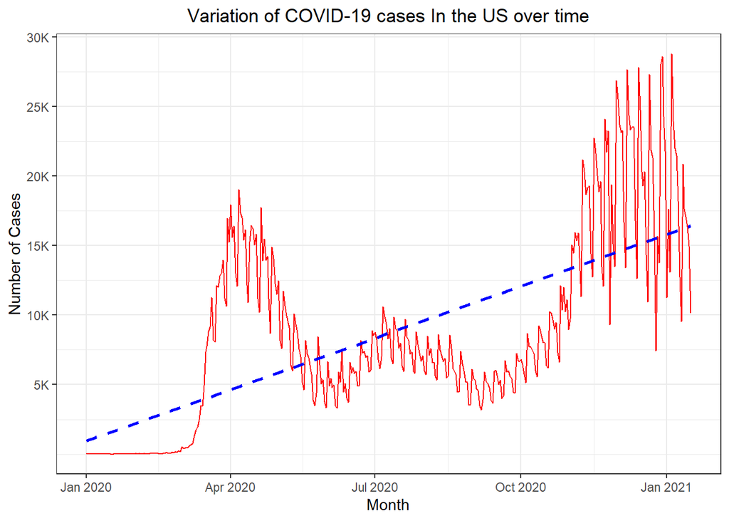

```r
# time series for all covid cases from jan 2020 till jan 2021 ####

# series by day

# grouping and finding the count
d_covid<-mydata1%>%filter(!is.na(hosp_yn))%>%filter(!is.na(icu_yn))%>% filter(!is.na(death_yn))%>%
  group_by(cdc_case_earliest_dt)%>%summarize(count=n())

#time_covid<- d_covid%>%left_join(holiday, by= 'cdc_case_earliest_dt')
ylab<-c(5,10,15,20,25,30)
#plot
d_covid%>% ggplot(aes(x=cdc_case_earliest_dt,y=count))+geom_line(color='red')+labs(title = 'Variation of COVID-19 cases In the US over time', x='Month', y='Number of Cases')+
  geom_smooth(method = 'lm', se=FALSE, linetype='dashed', color='blue')+theme_bw()+scale_y_continuous(labels = paste0(ylab, "K"),
                                                                                                      breaks = 10^3 * ylab )+
  ggeasy::easy_center_title()
```

The above figure illustrates the per-day COVID cases from January 2020 to January 2021. Three peaks/waves of COVID-19 cases can be observed, though the second wave is far subdued than the other two. The most recent wave had the most number of cases compared to others. This variation in the intensity of the 3 waves can be explained by the fact that during the initial days of the virus there was limited information regarding the spread and potency, but later on with mask mandates and stay at home orders the spread could be controlled for a certain time period. But again, the case-counts started rising around the summer. Most peaks can be noticed after a public holiday, and profound peaks can be observed after the Christmas and New Year breaks. However, this theory does not hold good for all public holidays.

$~$

Apart from the case counts we analyzed the underlying social demographic trends relating to the spread of COVID-19 among different age groups, races and gender. The next figure illustrates the case counts among different age groups, and their respective percentage contributions.

$~$

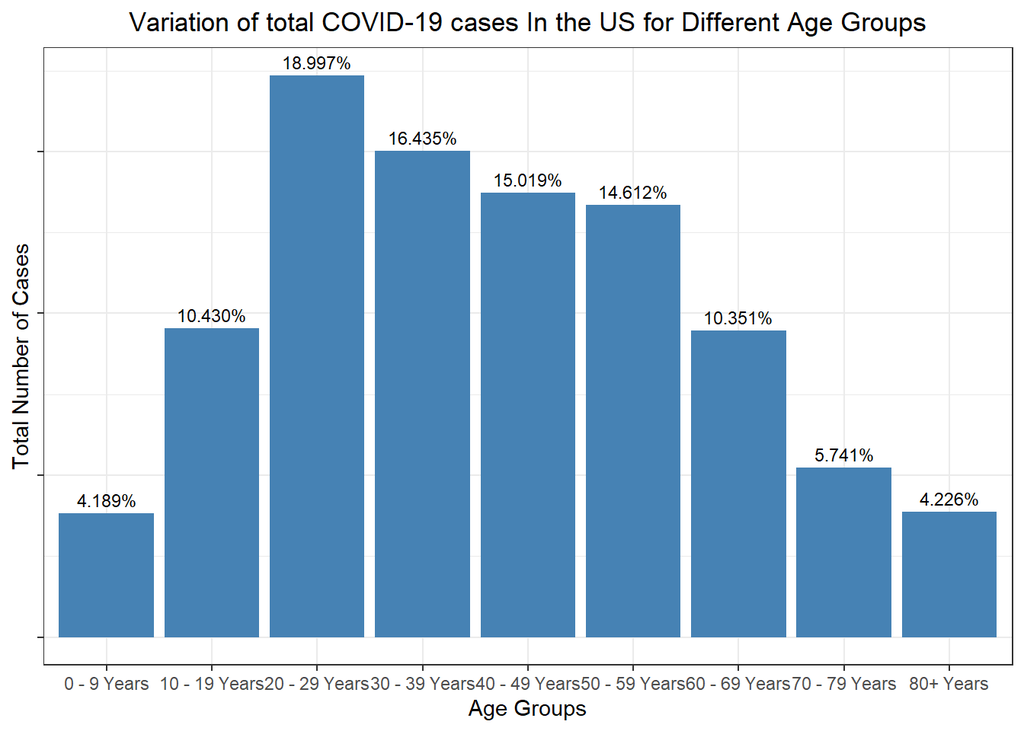

```r
# cases for differnet age groups
age_df<-mydata1%>%filter(!is.na(age_group)) %>%group_by(age_group)%>%summarize(count=n())%>% mutate(percentage=prop.table(count))
age_df%>% ggplot(aes(age_group,count,label = scales::percent(percentage)))+geom_bar(stat="identity",fill='SteelBlue')+
  labs(title = 'Variation of total COVID-19 cases In the US for Different Age Groups', x='Age Groups', y='Total Number of Cases')+
  theme_bw()+
  geom_text(position = position_dodge(width = .9),    # move to center of bars
            vjust = -0.5,                             # nudge above top of bar
            size = 3) +
  scale_y_continuous(labels = scales::percent_format(accuracy=1))+theme(axis.text.y = element_blank())+
  ggeasy::easy_center_title()
```

$~$

Against popular belief, this graph indicates that individuals in the age group between 20-29 had a 1 in 5 chance of being tested COVID-19 positive, which is the highest among all age groups. The oldest (80+ years) and the youngest (0-9 years) seem to have the lowest incidence of COVID-19 reported. This can be attributed to several factors like older people are more likely to stay home more, travel less, and are also advised to generally step out less often. Also, the 25-45 years age bracket would be part of the main group of essential workers, and hence they may have had more potential exposure to the virus.

$~$

```r
# all races analysis for covid cases ####
race_df<-mydata1%>%filter(!is.na(race_ethnicity_combined)) %>%group_by(race_ethnicity_combined)%>%summarize(count=n())%>%
  mutate(percentage=prop.table(count))%>% arrange(desc(percentage))
x<-race_df$race_ethnicity_combined
race_df$race_ethnicity_combined<-gsub("(.*),.*", "\\1", x)
# removing missing and unknown
# also removing '/'
x<-race_df$race_ethnicity_combined
race_df$race_ethnicity_combined<-gsub("(.*)/.*", "\\1", x)
race_df<-as_tibble(race_df)
# selecting only certain races
race_df %>% filter(race_df$race_ethnicity_combined %in%c("American Indian","Asian","Black","Hispanic","Multiple","Native Hawaiian","White"))
```

```
## # A tibble: 7 x 3
##   race_ethnicity_combined   count percentage
##   <chr>                     <int>      <dbl>
## 1 White                   5780900    0.315
## 2 Hispanic                1993532    0.108
## 3 Black                   1257101    0.0684
## 4 Multiple                 725433    0.0395
## 5 Asian                    367464    0.0200
## 6 American Indian          135974    0.00740
## 7 Native Hawaiian           35357    0.00192
```

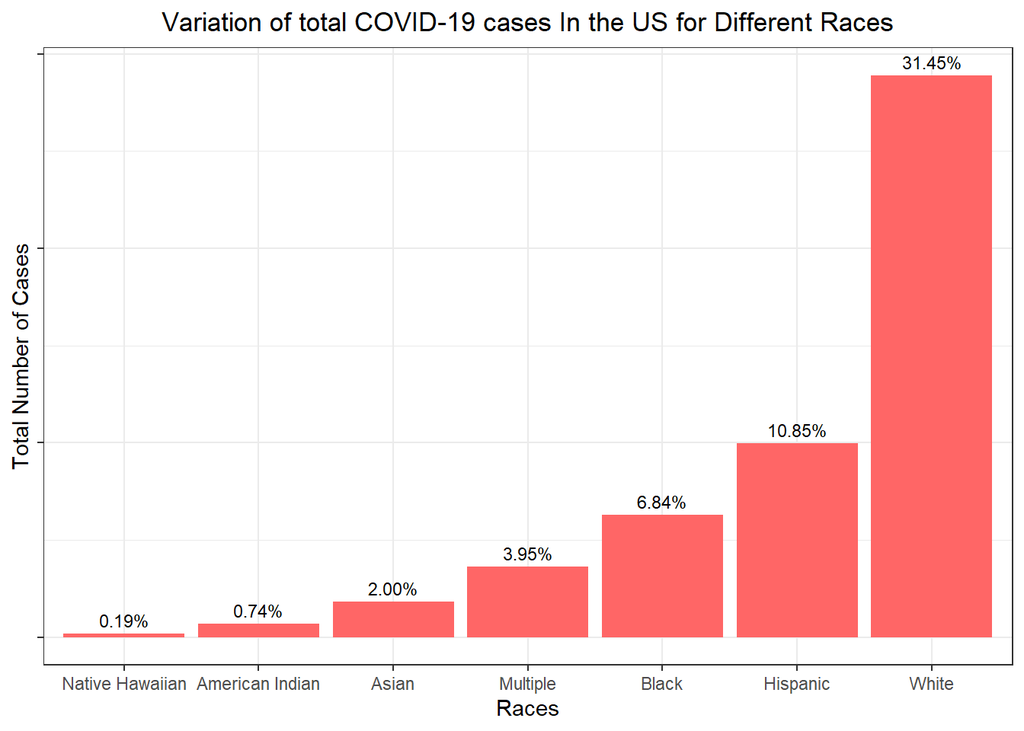

```r
race_df<-race_df%>% filter(race_ethnicity_combined != c("Unknown"))
race_df<-race_df %>% filter(race_ethnicity_combined != c("Missing"))

race_df%>% ggplot(aes(reorder(race_ethnicity_combined, count),count,label = scales::percent(percentage)))+geom_bar(stat="identity",fill='#FF6666')+
  labs(title = 'Variation of total COVID-19 cases In the US for Different Races', x='Races', y='Total Number of Cases')+
  geom_text(position = position_dodge(width = .9),    # move to center of bars
            vjust = -0.5,                             # nudge above top of bar
            size = 3) +
  scale_y_continuous(labels = scales::percent)+theme(axis.text.y = element_blank())+
  theme_bw()+ggeasy::easy_center_title()+theme(axis.text.y = element_blank())
```

$~$

$~$

```r
# removing the missing other and unknown sexes
sex_cases<-mydata1 %>%filter(!is.na(hosp_yn))%>%filter(!is.na(sex))%>%filter(!is.na(age_group)) %>%group_by(sex)%>%summarize(count=n())%>%
  mutate(percentage=prop.table(count))
sex_cases
```

```
## # A tibble: 5 x 3
##   sex       count percentage
##   <chr>     <int>      <dbl>
## 1 Female  5284543  0.523
## 2 Male    4736108  0.469
## 3 Missing   12991  0.00129
## 4 Other       186  0.0000184
## 5 Unknown   67737  0.00671
```

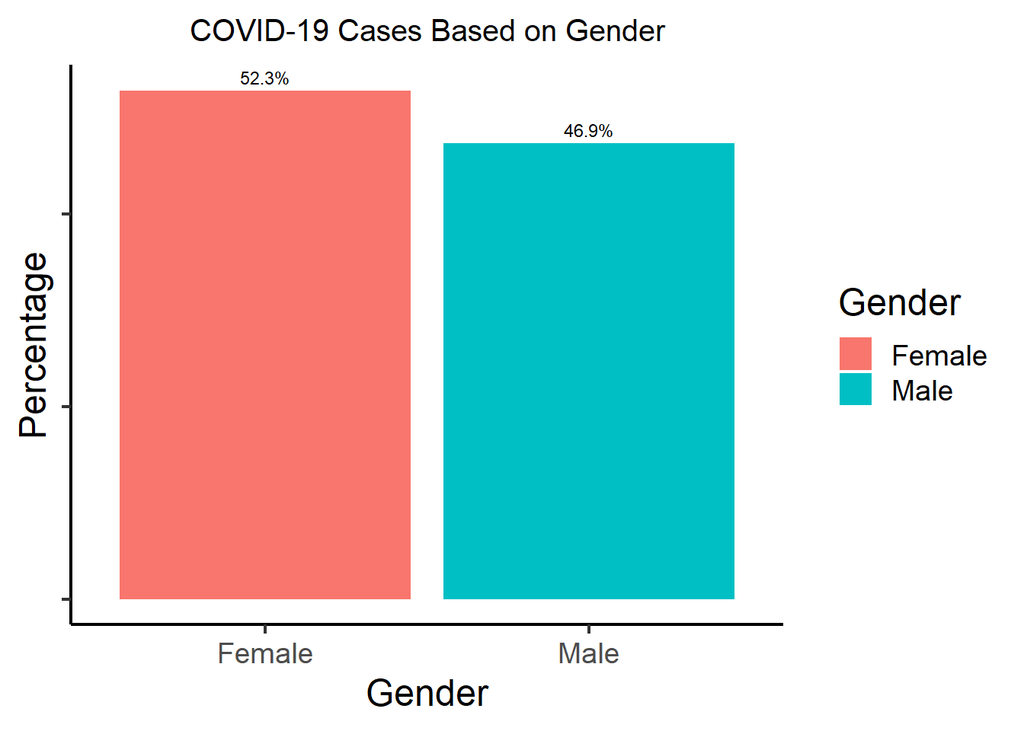

```r
sex_cases<-sex_cases%>%filter(sex %in% c('Female','Male'))
# sex_cases<-sex_cases%>%filter(hosp_yn %in% c('No','Yes'))
sex_cases%>% ggplot(aes(sex,count,fill=sex, label = scales::percent(percentage)
))+geom_bar(stat="identity",position ='dodge')+
  theme_classic(base_size = 18)+
  xlab("Gender")+
  ylab("Percentage")+
  labs(fill="Gender",title='COVID-19 Cases Based on Gender')+
  geom_text(position = position_dodge(width = .9),
                                        vjust = -0.5,
                                        size = 3) +
  scale_y_continuous(labels = scales::percent)+theme(axis.text.y = element_blank())+ggeasy::easy_center_title()+theme(plot.title=element_text(size=15))
```

$~$

### Hypothesis 1

**White Race would lead COVID-19 counts for all months**

From the exploratory analysis it was clear that White(s) dominated the number of COVID-19 cases by a ratio of about 1 in 3. The figure below shows a month wise breakdown of the cases for different ethnicities.

$~$

```r
#race analysis for each month

race_df<- mydata1 %>% filter(!is.na(race_ethnicity_combined)) %>% mutate(date_by_month= strftime(cdc_case_earliest_dt,'%m'))

race_df1<- race_df%>%filter(!is.na(medcond_yn))%>%filter(!is.na(icu_yn))%>%filter(!is.na(death_yn))%>%filter(!is.na(hosp_yn))

race_df_1<- race_df1 %>% group_by(race_ethnicity_combined, date_by_month)%>%summarize(count=n())%>%mutate(percentage=round(prop.table(count), 2))

race_df_1
```

```
## # A tibble: 107 x 4
## # Groups:   race_ethnicity_combined [9]
##    race_ethnicity_combined                     date_by_month count percentage
##    <chr>                                       <chr>         <int>      <dbl>
##  1 American Indian/Alaska Native, Non-Hispanic 01              760       0.1
##  2 American Indian/Alaska Native, Non-Hispanic 03              193       0.03
##  3 American Indian/Alaska Native, Non-Hispanic 04              497       0.07
##  4 American Indian/Alaska Native, Non-Hispanic 05              498       0.07
##  5 American Indian/Alaska Native, Non-Hispanic 06              500       0.07
##  6 American Indian/Alaska Native, Non-Hispanic 07              693       0.09
##  7 American Indian/Alaska Native, Non-Hispanic 08              621       0.08
##  8 American Indian/Alaska Native, Non-Hispanic 09              554       0.08
##  9 American Indian/Alaska Native, Non-Hispanic 10              817       0.11
## 10 American Indian/Alaska Native, Non-Hispanic 11             1051       0.14
## # ... with 97 more rows
```

```r
x<-race_df_1$race_ethnicity_combined
race_df_1$race_ethnicity_combined<-gsub("(.*),.*", "\\1", x)
x<-race_df_1$race_ethnicity_combined
race_df_1$race_ethnicity_combined<-gsub("(.*)/.*", "\\1", x)
# removing missing and unknown
race_df_1<-as_tibble(race_df_1)
race_df_1 %>% filter(race_df_1$race_ethnicity_combined %in%
                     c("American Indian","Asian","Black","Hispanic","Multiple","White"))
```

```
## # A tibble: 71 x 4
##    race_ethnicity_combined date_by_month count percentage
##    <chr>                   <chr>         <int>      <dbl>
##  1 American Indian         01              760       0.1
##  2 American Indian         03              193       0.03
##  3 American Indian         04              497       0.07
##  4 American Indian         05              498       0.07
##  5 American Indian         06              500       0.07
##  6 American Indian         07              693       0.09
##  7 American Indian         08              621       0.08
##  8 American Indian         09              554       0.08
##  9 American Indian         10              817       0.11
## 10 American Indian         11             1051       0.14
## # ... with 61 more rows
```

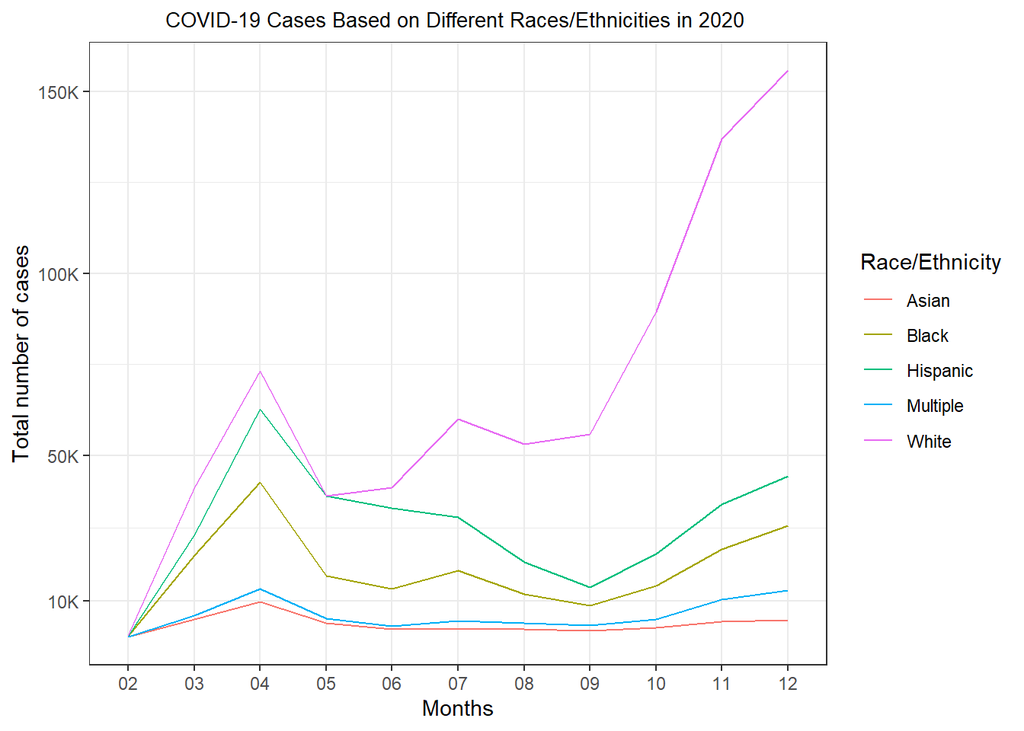

```r
race_df_1<-race_df_1%>% filter(race_ethnicity_combined != c("Unknown"))
race_df_1<-race_df_1 %>% filter(race_ethnicity_combined != c("Missing"))
race_df_1<-race_df_1 %>% filter(race_ethnicity_combined != c("Native Hawaiian"))
race_df_1<-race_df_1 %>% filter(race_ethnicity_combined != c("American Indian"))
race_df_1<-race_df_1%>% filter(date_by_month!=c('01'))



ylab=c(10, 50, 100,150, 200)
race_df_1%>% ggplot(aes(y=count,x= date_by_month,group=race_ethnicity_combined, color=race_ethnicity_combined, fill=race_ethnicity_combined))+
  geom_line()+
  labs(title = 'COVID-19 Cases Based on Different Races/Ethnicities in 2020 ',
       x='Months', y='Total number of cases')+theme(legend.position = 'none')+
  ggeasy::easy_center_title()+scale_y_continuous(labels = paste0(ylab, "K"),breaks = 10^3 * ylab )+theme_bw()+
  ggeasy::easy_center_title()+scale_color_discrete(name='Race/Ethnicity')+theme(plot.title=element_text(size=10))
```

$~$

*Results/Discussion*

### Hypothesis 2

**20-29 Age Group would lead COVID-19 counts for all months**

From the exploratory analysis it was clear that, 20-29 age group seems to dominate (1 in every 5 cases), so we expected this age group to have the highest number of COVID-19 cases for every month.

$~$

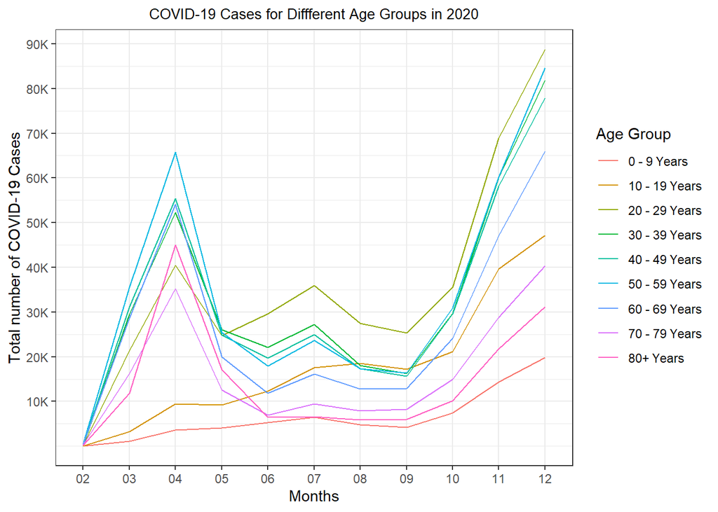

```r
#age analysis for each month
age_df1<-mydata1%>%filter(!is.na(race_ethnicity_combined)) %>% filter(!is.na(age_group))%>%filter(!is.na(medcond_yn))%>%
  filter(!is.na(icu_yn))%>%filter(!is.na(death_yn))%>%filter(!is.na(hosp_yn))




age_df<-age_df1%>%mutate(date_by_month= strftime(cdc_case_earliest_dt,'%m'))%>%
  group_by(date_by_month,age_group)%>%
  summarize(count=n())%>%mutate(percentage=prop.table(count))

age_df<-age_df%>% filter(date_by_month!=c('01'))



ylab=c(10,20,30,40,50,60,70,80,90,100)
age_df%>% ggplot(aes(y=count,x= date_by_month,color=age_group, group=age_group))+
  geom_line()+
  labs(title = 'COVID-19 Cases for Diffferent Age Groups in 2020' ,
       x='Months', y='Total number of COVID-19 Cases')+
  theme(legend.position = 'none')+theme_bw()+
  scale_color_discrete(name='Age Group')+
  ggeasy::easy_center_title()+scale_y_continuous(labels = paste0(ylab, "K"),breaks = 10^3 * ylab )+
  theme(plot.title=element_text(size=10))
```

$~$

*Results/Discussion*

The above graph depicts the variation of COVID-19 cases for different age groups across the previous year, and the various age groups can be seen by different colored bars. Since we had seen that 20-29 age groups had the most share of cases in the United States, we expected them to dominate each month’s case counts. But as we can see from the graph, this was not the case in March, April, and May. After June (06), the 20-29 age group seems to dominate till the end of the year. This means, almost half of the year, they were behind the case counts, but in the last half of the year, they had so many cases that they ended up with the highest percentage of cases for all age groups. Additionally, we can also see that the age groups (60+) initially had quite a number of cases which slowly reduced but again increased towards the later part of the year

### Hypothesis 3

**Women have higher hospitalization and Intensive Care unit ( ICU )occupancy rates**

$~$

```r
# hospital cases men vs women ####
hos_cases<-mydata1 %>%filter(!is.na(hosp_yn))%>%filter(!is.na(sex)) %>%group_by(hosp_yn,sex)%>%summarize(count=n())%>%
  mutate(percentage=prop.table(count))
hos_cases
```

```
## # A tibble: 18 x 4
## # Groups:   hosp_yn [4]
##    hosp_yn sex       count percentage
##    <chr>   <chr>     <int>      <dbl>
##  1 No      Female  3333803  0.534
##  2 No      Male    2865096  0.459
##  3 No      Missing    8396  0.00135
##  4 No      Other       176  0.0000282
##  5 No      Unknown   31368  0.00503
##  6 OTH     Female      587  0.495
##  7 OTH     Male        580  0.489
##  8 OTH     Unknown      20  0.0168
##  9 Unknown Female  1540214  0.514
## 10 Unknown Male    1415459  0.473
## 11 Unknown Missing    4339  0.00145
## 12 Unknown Other        37  0.0000124
## 13 Unknown Unknown   34963  0.0117
## 14 Yes     Female   414326  0.473
## 15 Yes     Male     458969  0.524
## 16 Yes     Missing     540  0.000617
## 17 Yes     Other        22  0.0000251
## 18 Yes     Unknown    2028  0.00232
```

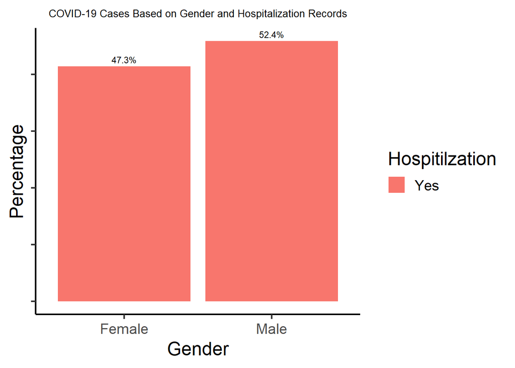

```r
# removing the missing other and unknown sexes
hos_cases<-hos_cases%>%filter(sex %in% c('Female','Male'))
hos_cases<-hos_cases%>%filter(hosp_yn %in% c('Yes'))
hos_cases%>% ggplot(aes(sex,count,fill=hosp_yn, label = scales::percent(percentage)
))+geom_bar(stat="identity",position ='dodge')+
  theme_classic(base_size = 18)+
  xlab("Gender")+
  ylab("Percentage")+
  labs(fill="Hospitilzation",title='COVID-19 Cases Based on Gender and Hospitalization Records', size=5)+
  geom_text(position = position_dodge(width = .9),
                                        vjust = -0.5,
                                        size = 3) +
  scale_y_continuous(labels = scales::percent)+theme(axis.text.y = element_blank())+ggeasy::easy_center_title()+theme(plot.title=element_text(size=10))
```

$~$

*Results/Discussion*

$~$

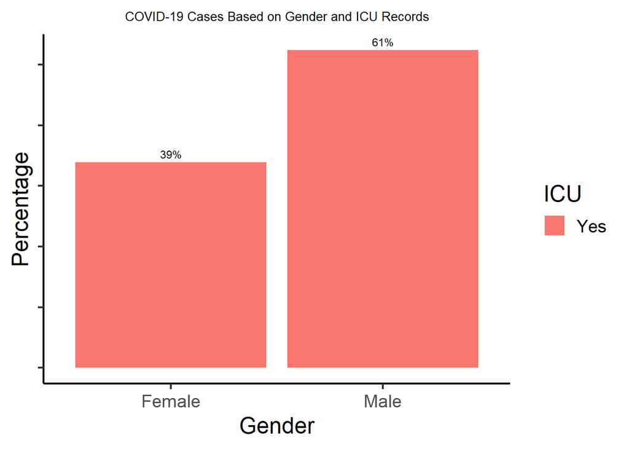

```r
#icu cases men women ####
icu_cases<-mydata1 %>%filter(!is.na(hosp_yn))%>%filter(!is.na(sex)) %>%group_by(icu_yn,sex)%>%summarize(count=n())%>%
  mutate(percentage=prop.table(count))
# removing the missing other and unknown sexes
icu_cases<-icu_cases%>%filter(sex %in% c('Female','Male'))
icu_cases<-icu_cases%>%filter(icu_yn %in% c('Yes'))
icu_cases%>% ggplot(aes(sex,count,fill=icu_yn,label = scales::percent(percentage)))+geom_bar(stat="identity",position ='dodge')+
  theme_classic(base_size = 18)+
  xlab("Gender")+
  ylab("Percentage")+
  labs(fill="ICU")+geom_text(position = position_dodge(width = .9),
                             vjust = -0.5,
                             size = 3) + labs(title = 'COVID-19 Cases Based on Gender and ICU Records')+
  scale_y_continuous(labels = scales::percent)+ggeasy::easy_center_title()+theme(axis.text.y = element_blank())+theme(plot.title=element_text(size=10))
```

$~$ *Results/Discussion*

This graph describes ICU admissions (in percent) for males and females due to COVID-19. From the graph, we can decipher that the males here as well dominate the females, which therefore leads us to conclude that COVID-19 has been more detrimental or has more severe symptoms on men as compared to women. Therefore our hypothesis is not proven to be true in this case. Well, it will be interesting to know how does the ICU admissions correlate with the death count among the different genders

### Conclusion

The present study modeled COVID related data. The major takeaways of this study are:

1. Analysis of COVID-19 cases among different races and ethnicities showed that Whites are severely affected by COVID-19, especially in the last four months of 2020. This is followed by Hispanics and Blacks.In the future a better way would be to account for the actual percentage of population of each ethnic groups against their case numbers for a better understanding.
2. Analyzing different age groups showed that the 20-29 age group had the most share of cases in the United States for most months of the year barring March, April and May. Similarly for this analysis as well we would benefit from knowing the actual cases of each age group against their numbers as a range of all people in the US
3. Females tend to have more COVID-19 cases than men in general. But when looking into hospitalization records and intensive care units’ records, males have higher hospitalization and ICU admission rates. In the future we would analyze if males tend to be more to having underlying medical conditions, which in turn caused them to be far more susceptible to being hospitalized after catching the Coronavirus